# A—21058-2021-09-16

# Question

Use knitr to produce at least 3 examples (texts, figures, tables)

# Answer

```r
a<-"hello world"
a
```

```
## [1] "hello world"
```

```r
substr(a,7,11)
```

```
## [1] "world"
```

```r
aa<-c("hello","world")
aa
```

```
## [1] "hello" "world"
```

```r
aa[1]
```

```
## [1] "hello"
```

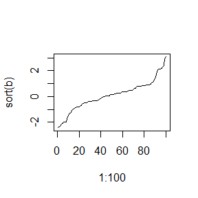

```r
b<-rnorm(100)
plot(1:100,sort(b),type="l")
```

```r
c<-table(c(1,2,3,4,5,6,5,4,3,2,1))
c
```

```
##
## 1 2 3 4 5 6
## 2 2 2 2 2 1
```

```r
set.seed(2021917)
matrix(rexp(9),nrow = 3,ncol = 3)
```

```
##            [,1]      [,2]      [,3]
## [1,] 0.03165167 2.8175000 2.0963544
## [2,] 0.32027598 0.3947838 0.2152053
## [3,] 1.45222534 0.2584574 0.3313859
```

```r
d<-data.frame(1,1:10)

d[1:10,2]
```

```
##  [1]  1  2  3  4  5  6  7  8  9 10
```

# Question 3.4

Develop an algorithm to generate random samples from a Rayleigh(σ) distri- bution. Generate Rayleigh(σ) samples for several choices of σ > 0 and check that the mode of the generated samples is close to the theoretical mode σ (check the histogram).

# Answer

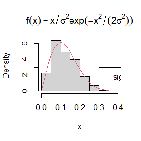

```r
n <- 1000
sigma=0.1
u <- runif(n)
x <- sqrt(-2*sigma^2*log(1-u))
hist(x, prob = TRUE, main = expression(f(x)==x/sigma^2*exp(-x^2/(2*sigma^2))))
y <- seq(0, 0.4, .01)
lines(y, y/sigma/sigma*exp(-y^2/2/sigma/sigma),col=2)
legend(0.3,3,legend="sigma=0.1")
```

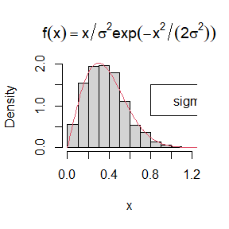

```r
n <- 1000
sigma=0.3
u <- runif(n)
x <- sqrt(-2*sigma^2*log(1-u))
hist(x, prob = TRUE, main = expression(f(x)==x/sigma^2*exp(-x^2/(2*sigma^2))))
y <- seq(0, 1.4, .01)
lines(y, y/sigma/sigma*exp(-y^2/2/sigma/sigma),col=2)
legend(0.8,1.5,legend="sigma=0.3")
```

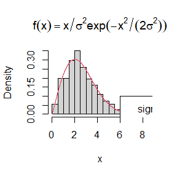

```r
n <- 1000
sigma=2
u <- runif(n)
x <- sqrt(-2*sigma^2*log(1-u))
hist(x,breaks = 15, prob = TRUE, main = expression(f(x)==x/sigma^2*exp(-x^2/(2*sigma^2))))
y <- seq(0, 6, .001)
lines(y, y/sigma/sigma*exp(-y^2/2/sigma/sigma),col=2)
legend(6,0.1,legend="sigma=2")
```

# Question 3.11

Generate a random sample of size 1000 from a normal location mixture. The components of the mixture have N(0,1) and N(3,1) distributions with mixing probabilities p 1 and p 2 = 1 − p 1 . Graph the histogram of the sample with density superimposed, for p 1 = 0.75. Repeat with different values for p 1 and observe whether the empirical distribution of the mixture appears to be bimodal. Make a conjecture about the values of p 1 that produce bimodal mixtures.

# Answer

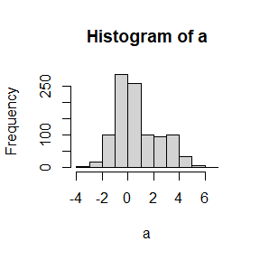

```r
n<-1000
x <- rnorm(n)
y <- rnorm(n,mean = 3)
p1=0.75
p2=0.25
xx<-sample(x,size = n*p1)
yy<-sample(y,size = n*p2)
a<-c(xx,yy)
hist(a)
```

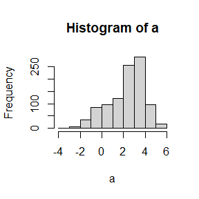

```r
n<-1000
x <- rnorm(n)
y <- rnorm(n,mean = 3)
p1=0.25
p2=0.75
xx<-sample(x,size = n*p1)
yy<-sample(y,size = n*p2)
a<-c(xx,yy)
hist(a)
```

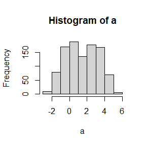

```r
n<-1000
x <- rnorm(n)
y <- rnorm(n,mean = 3)
p1=0.5
p2=0.5
xx<-sample(x,size = n*p1)
yy<-sample(y,size = n*p2)
a<-c(xx,yy)
hist(a)
```

# Question

A compound Poisson process is a stochastic process {X(t),t ≥ 0} that can be represented as the random sum $X(t)=\sum_{i=1}^{N(t)}Y_i$ t ≥ 0, where {N(t),t ≥ 0} is a Poisson process and Y 1 ,Y 2 ,… are iid and independent of {N(t),t ≥ 0}. Write a program to simulate a compound Poisson(λ)–Gamma process (Y has a Gamma distribution). Estimate the mean and the variance of X(10) for several choices of the parameters and compare with the theoretical values. Hint: Show that E[X(t)] = λtE[Y1] and Var(X(t)) = λtE[Y1^2].

# Answer

```r
a<-c()
for(j in 1:100){
N<-rpois(10,5)
x0<-rgamma(N,1)
a[j]<-(sum(x0[1:10]))
}
a
```

```
##   [1] 14.926006  7.804658  7.380346  7.534861  6.973468  7.786424 15.637569
##   [8] 10.491416  9.804268 10.698379 10.102836  8.801783  9.012466 11.101932
##  [15] 11.164242 10.481735 12.969082  5.276689  5.797265  7.458737  6.454625
##  [22]  9.856144 11.347099 13.017223 19.698614  4.912839  8.225615  5.363721
##  [29] 16.034423 17.375675  9.093045 15.651307 11.785803  9.213497 13.765869
##  [36] 14.549801 11.975741  5.493752 13.672605  9.607795  7.423570 12.952384
##  [43]  7.980252  9.736758  6.374467  7.575541  8.402018  7.786418  8.166720
##  [50] 12.517738  7.501773  6.813026  8.284195 13.480831 10.606301 10.820147
##  [57]  7.403874  6.601455 10.206855 16.660622 11.406879  7.838381 12.500054
##  [64] 12.124924 10.508716  7.557264 11.861710 11.877885  6.180084 12.716158
##  [71]  8.618805  9.103618  6.242398 11.908600  7.824446 10.363272 10.664508
##  [78]  9.600529 12.013424 10.239067  8.216564  6.483608  7.873052 10.231337
##  [85]  7.794364  9.239032 12.450166 11.418709  9.736158  8.787569  7.787830
##  [92]  6.334514  9.660684  5.535706 10.355571  9.225896  8.239707  7.725219
##  [99]  9.278437  7.573623
```

```r
mean(a)
```

```
## [1] 9.806928
```

```r
var(a)
```

```
## [1] 8.444654
```

```r
a<-c()
for(j in 1:100){
N<-rpois(10,5)
x0<-rgamma(N,3)
a[j]<-(sum(x0[1:10]))
}
mean(a)
```

```
## [1] 31.31902
```

```r
var(a)
```

```
## [1] 20.62787
```

```r
a<-c()
for(j in 1:100){
N<-rpois(10,10)
x0<-rgamma(N,3)
a[j]<-(sum(x0[1:10]))
}
a
```

```
##   [1] 26.94063 32.57090 28.93332 32.98333 27.96157 26.86326 29.25300 21.16355
##   [9] 35.90048 33.24189 28.98134 31.04070 24.80987 31.67904 32.45480 29.70806
##  [17] 22.69540 24.90718 33.09988 30.60877 33.33790 32.83736 32.09634 34.05758
##  [25] 25.63823 30.79486 29.81079 29.28071 40.06816 32.93553 32.94251 33.32087
##  [33] 30.04032 33.78370 38.29629 31.04201 29.18535 30.43497 35.14630 34.22215
##  [41] 15.90475 37.50992 27.14595 26.31286 24.23929 34.09780 41.33151 18.92791
##  [49] 32.86680 22.86664 32.80114 28.41100 24.75500 22.60021 32.25142 26.79107
##  [57] 41.30716 28.95007 36.31064 20.96250 33.30687 40.97742 29.90381 31.36809
##  [65] 25.82094 27.27536 22.82167 33.68269 24.22340 35.28334 32.21662 43.15731
##  [73] 32.68501 31.94763 29.08131 28.32689 22.69762 31.21028 42.13275 28.89946
##  [81] 31.44817 32.15920 39.18514 34.78387 29.37101 28.35966 34.86391 23.82850
##  [89] 29.36802 35.24437 22.19328 33.96189 33.50099 26.04600 22.44869 30.80937
##  [97] 23.26703 34.38872 28.43380 20.97719
```

```r
mean(a)
```

```
## [1] 30.3307
```

```r
var(a)
```

```
## [1] 28.21057
```

# 5.4

```r
pbetaa<-function(xx){
  m=1e4
  x=runif(m,min=0,max=xx)
  theta=mean(30*xx*x^2*(1-x)^2)
  return(theta)
}
print(c(pbetaa(0.1),pbeta(0.1,3,3)))
```

```
## [1] 0.008606236 0.008560000
```

```r
print(c(pbetaa(0.2),pbeta(0.2,3,3)))
```

```
## [1] 0.05805774 0.05792000
```

```r
print(c(pbetaa(0.3),pbeta(0.3,3,3)))
```

```
## [1] 0.163031 0.163080
```

```r
print(c(pbetaa(0.4),pbeta(0.4,3,3)))
```

```
## [1] 0.3155059 0.3174400
```

```r
print(c(pbetaa(0.5),pbeta(0.5,3,3)))
```

```
## [1] 0.5007651 0.5000000
```

```r
print(c(pbetaa(0.6),pbeta(0.6,3,3)))
```

```
## [1] 0.6821784 0.6825600
```

```r
print(c(pbetaa(0.7),pbeta(0.7,3,3)))
```

```
## [1] 0.8409837 0.8369200
```

```r
print(c(pbetaa(0.8),pbeta(0.8,3,3)))
```

```
## [1] 0.9505345 0.9420800
```

```r
print(c(pbetaa(0.9),pbeta(0.9,3,3)))
```

```
## [1] 0.9994968 0.9914400
```

# 5.9

```r
Ra<-1000
x<-1
u <- runif(Ra/2)
v <- 1 - u
g<- numeric(length=(Ra/2))
sigma=0.1

for (i in 1:(Ra/2)) {
g[i] <- x*u[i] * exp(-u[i]^2 / (2*sigma^2))/sigma^2
g[i] <- g[i]+x*v[i] * exp(-v[i]^2 / (2*sigma^2))/sigma^2
g[i] <- g[i]/2
}
var(g)
```

```
## [1] 1.215549
```

```r
g1<-var(g)

u <- runif(Ra/2)
v <- runif(Ra/2)
g<- numeric(length=(Ra/2))

for (i in 1:(Ra/2)) {
g[i] <- x*u[i] * exp(-u[i]^2 / (2*sigma^2))/sigma^2
g[i] <- g[i]+x*v[i] * exp(-v[i]^2 / (2*sigma^2))/sigma^2
g[i] <- g[i]/2
}
var(g)
```

```
## [1] 1.597907
```

```r
g2<-var(g)
(g2-g1)/g2*100
```

```
## [1] 23.92866
```

# 5.13

```r
m <- 1000
theta.hat <- se <- numeric(5)
g <- function(x) {
exp(-x^2/2 +log(x^2/sqrt(2*pi)))*(x>1)
}

g0 <- function(x) {
exp(-x^2/2 +log(x^2/sqrt(2*pi)))*(x<1)*(x>0)
}

x <- runif(m) #f0=1
fg <- 1/2-g0(x)
theta.hat[1] <- mean(fg)
se[1] <- sd(fg)

u<-runif(m)
x <- -log(1-u) #f1=e^-x
fg <- 1/2-g0(x) / exp(-x)
theta.hat[2] <- mean(fg)
se[2] <- sd(fg)

u <- runif(m,0,1) #f2=xe^{-x^2/2}, x>0,inverse transform method
x <- sqrt(- 2*log(1-u))
fg <-1/2- g0(x) / x/(exp(-x^2/2) )
theta.hat[3] <- mean(fg)
se[3] <- sd(fg)

u <- runif(m,0,1) #f3=2xe^{-x^2/2}, x>0,inverse transform method
x <- sqrt(- 2*log(1-u/2))
fg <-1/2-g0(x) / x/(exp(-x^2/2) )/2
theta.hat[4] <- mean(fg)
se[4] <- sd(fg)

u <- runif(m,0,1) #f4=3xe^{-x^2/2}, x>0,inverse transform method
x <- sqrt(- 2*log(1-u/3))
fg <-1/2-g0(x) / x/(exp(-x^2/2) )/3
theta.hat[5] <- mean(fg)
se[5] <- sd(fg)

theta.hat
```

```
## [1] 0.4012724 0.4046863 0.4008748 0.3991917 0.4230492
```

```r
se
```

```
## [1] 0.07705369 0.15614385 0.13630841 0.06644579 0.02873197
```

# 5.14

0.401~0.402

## 6.5

# question

Suppose a 95% symmetric t-interval is applied to estimate a mean, but the sample data are non-normal. Then the probability that the confidence interval covers the mean is not necessarily equal to 0.95. Use a Monte Carlo experiment to estimate the coverage probability of the t-interval for random samples of χ2(2) data with sample size n = 20. Compare your t-interval results with the simulation results in Example 6.4. (The t-interval should be more robust to departures from normality than the interval for variance.)

# answer

```r
n<-20
alpha=0.05
t<-qt(0.975,(n-2))
re<-0
for(i in 1:1000){
  x<-rchisq(n,2)
  if(((mean(x)-t*sd(x))<2)&(2<(mean(x)+t*sd(x)))) re<-re+1
  else re<-re
}
re/1000
```

```
## [1] 1
```

## 6.A

# question

Use Monte Carlo simulation to investigate whether the empirical Type I error rate of the t-test is approximately equal to the nominal significance level α, when the sampled population is non-normal. The t-test is robust to mild departures from normality. Discuss the simulation results for the cases where the sampled population is (i) χ2(1), (ii) Uniform(0,2), and (iii) Exponential(rate=1). In each case, test H0 : µ = µ0 vs H0 : µ = µ0, where µ0 is the mean of χ2(1), Uniform(0,2), and Exponential(1), respectively.

# answer

```r
alpha <- 1; beta <- 0 # null hypothesis!
m <- 1e3; n <- 10; set.seed(123)
beta.hat <- beta.se <- p.val1 <- numeric(m)
x <- rchisq(n,1)
for(i in 1:m){
y <- alpha + beta * x + rt(n,2)
coe <- summary(lm(y~x))$coef
beta.hat[i] <- coe[2,1];beta.se[i] <- coe[2,2]
p.val1[i] <- coe[2,4] # t-test p-value
}
p.val2 <- 2*(1-pt(abs(beta.hat/beta.se),n-2))
print(c(mean(p.val1<=0.05),mean(p.val2<=0.05)))
```

```
## [1] 0.051 0.051
```

```r
alpha <- 1; beta <- 0 # null hypothesis!
m <- 1e3; n <- 10; set.seed(123)
beta.hat <- beta.se <- p.val1 <- numeric(m)
x <- runif(n,0,2)
for(i in 1:m){
y <- alpha + beta * x + rt(n,2)
coe <- summary(lm(y~x))$coef
beta.hat[i] <- coe[2,1];beta.se[i] <- coe[2,2]
p.val1[i] <- coe[2,4] # t-test p-value
}
p.val2 <- 2*(1-pt(abs(beta.hat/beta.se),n-2))
print(c(mean(p.val1<=0.05),mean(p.val2<=0.05)))
```

```
## [1] 0.059 0.059
```

```r
alpha <- 1; beta <- 0 # null hypothesis!
m <- 1e3; n <- 10; set.seed(123)
beta.hat <- beta.se <- p.val1 <- numeric(m)
x <- rexp(n)
for(i in 1:m){
y <- alpha + beta * x + rt(n,2)
coe <- summary(lm(y~x))$coef
beta.hat[i] <- coe[2,1];beta.se[i] <- coe[2,2]
p.val1[i] <- coe[2,4] # t-test p-value
}
p.val2 <- 2*(1-pt(abs(beta.hat/beta.se),n-2))
print(c(mean(p.val1<=0.05),mean(p.val2<=0.05)))
```

```
## [1] 0.071 0.071
```

# question

If we obtain the powers for two methods under a particular simulation setting with 10,000 experiments: say, 0.651 for one method and 0.676 for another method. We want to know if the powers are different at 0.05 level.

# answer

```r
a<-matrix(c(6510,3490,6760,3240),ncol = 2)
xq<-0
for(i in 1:2){
  for(j in 1:2){
   xq<-xq+a[i,j]^2/sum(a[i,])/sum(a[,j])
  }
}
20000*(xq-1)
```

```
## [1] 13.99665
```

# Example 6.8:

```r
library(mvtnorm)
n <- c(10, 20, 30, 50, 100, 500) #sample sizes
d<-2
cv <- qchisq(0.95,d*(d+1)*(d+2)/6) #crit. values for each n
p.reject <- numeric(length(n)) #to store sim. results
m <- 1000 #num. repl. each sim.

sk <- function(x,n) {#computes the sample skewness coeff.
xbar <- colMeans(x)
sig<-solve((n-1)*cov(x)/n)
bb<-function(x) x-xbar
y<-apply(x,1,bb)
y<-t(y)
z<-(y%*%sig%*%t(y))^3
return(mean(z)/6)
}

for (i in 1:length(n)) {
sktests <- numeric(m) #test decisions
for (j in 1:m) {
x <- rmvnorm(n[i],rep(0,d),diag(d))
#test decision is 1 (reject) or 0
sktests[j] <- as.integer(n[i]*abs(sk(x,n[i])) >= cv )
}
p.reject[i] <- mean(sktests) #proportion rejected
}
p.reject
```

```
## [1] 0.006 0.025 0.025 0.033 0.059 0.051
```

# Example 6.10:

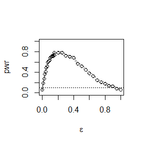

```r
alpha <- .1
n <- 30
m <- 500
epsilon <- c(seq(0, .15, .01), seq(.15, 1, .05))
N <- length(epsilon)
pwr <- numeric(N)
x<-matrix(0,nrow=n,ncol=d)
#critical value for the skewness test
cv <- qchisq(1-alpha, d*(d+1)*(d+2)/6)
for (j in 1:N) { #for each epsilon
  e <- epsilon[j]
  sktests <- numeric(m)

  for (i in 1:m) { #for each replicate
    sigma <- sample(c(1, 10), replace = TRUE,size = n, prob = c(1-e, e))
    for(k in 1:n) {
      t<-rmvnorm(1, rep(0,d),diag(rep(sigma[k],d)))
      x[k,] <-t(as.matrix(t[1,]))
      }
    sktests[i] <- as.integer(n*abs(sk(x,n)) >= cv)
}
pwr[j] <- mean(sktests)
}
#plot power vs epsilon
plot(epsilon, pwr, type = "b",
xlab = bquote(epsilon), ylim = c(0,1))
abline(h = .1, lty = 3)
se <- sqrt(pwr * (1-pwr) / m) #add standard errors
lines(epsilon, pwr+se, lty = 3)
lines(epsilon, pwr-se, lty = 3)
```

# 7.7

```r
data(patch, package = "bootstrap")
n <- nrow(patch)
B<-100
fpc<-c()
for(b in 1:B){
xstar <- sample(c(1:n),replace=TRUE)
patchstar<-patch[xstar,2:6]
r<-eigen((n-1)*cov(patchstar)/n)$values
fpc[b]<-r[1]/sum(r)
}
r0<-eigen((n-1)*cov(patch[,2:6])/n)$values
fpc0<-r0[1]/sum(r0)
fpcstar<-mean(fpc)
sefpc<-sd(fpc)
round(c(original=fpc0,bias=fpcstar-fpc0,se=sefpc),3)
```

```
## original     bias       se
##    0.911   -0.011    0.059
```

# 7.8

```r
fpcj<-numeric(n)
for (i in 1:n){
patchi<-patch[-i,2:6]
r<-eigen((n-1)*cov(patchi)/n)$values
fpcj[i]<-r[1]/sum(r)
}
bias <- (n - 1) * (mean(fpcj) - fpc0)
se <- sqrt((n-1)*mean((fpcj - mean(fpcj))^2))
round(c(original=fpc0,bias=bias,se=se),3)
```

```
## original     bias       se
##    0.911   -0.023    0.082
```

# 7.9

```r
library(boot)
boot.fpc<-function(x,i){
  n<-nrow(x)
  r<-eigen((n-1)*cov(x[i,1:5])/n)$values
  fpc<-r[1]/sum(r)
  fpc
}
de<-boot(data = patch[,2:6],statistic = boot.fpc,R = 999)
ci<-boot.ci(de,type = c("perc","bca"))
ci.perc<-ci$percent[4:5]
ci.bca<-ci$bca[4:5]
ci.perc
```

```
## [1] 0.7628046 0.9848845
```

```r
ci.bca
```

```
## [1] 0.7633512 0.9852339
```

# 7.B

```r
boot.ske<-function(x,i) mean(((x[i]-mean(x[i]))/sd(x[i]))^3)
ci.norm<-ci.basic<-ci.perc<-ci.bca<-matrix(NA,1000,2)

for(i in 1:100){
  x<-rnorm(100)
  de<-boot(data = x,statistic = boot.ske,R=99)
  ci<-boot.ci(de,type = c("norm","basic","perc"))
  ci.norm[i,]<-ci$norm[2:3]
  ci.basic[i,]<-ci$basic[4:5]
  ci.perc[i,]<-ci$percent[4:5]
}
c(mean(ci.norm[,1]),mean(ci.norm[,2]))
```

```
## [1] NA NA
```

```r
c(mean(ci.basic[,1]),mean(ci.basic[,2]))
```

```
## [1] NA NA
```

```r
c(mean(ci.perc[,1]),mean(ci.perc[,2]))
```

```
## [1] NA NA
```

```r
mean(ci.norm[,1]>0)
```

```
## [1] NA
```

```r
mean(ci.norm[,2]<0)
```

```
## [1] NA
```

```r
mean(ci.basic[,1]>0)
```

```
## [1] NA
```

```r
mean(ci.basic[,2]<0)
```

```
## [1] NA
```

```r
mean(ci.perc[,1]>0)
```

```
## [1] NA
```

```r
mean(ci.perc[,2]<0)
```

```
## [1] NA
```

```r
1-mean(ci.norm[,1]>0)-mean(ci.norm[,2]<0)
```

```
## [1] NA
```

```r
1-mean(ci.basic[,1]>0)-mean(ci.basic[,2]<0)
```

```
## [1] NA
```

```r
1-mean(ci.perc[,1]>0)-mean(ci.perc[,2]<0)
```

```
## [1] NA
```

```r
a<-sqrt(8/5)
for(i in 1:100){
  x<-rchisq(100,5)
  de<-boot(data = x,statistic = boot.ske,R=99)
  ci<-boot.ci(de,type = c("norm","basic","perc"))
  ci.norm[i,]<-ci$norm[2:3]
  ci.basic[i,]<-ci$basic[4:5]
  ci.perc[i,]<-ci$percent[4:5]
}
c(mean(ci.norm[,1]),mean(ci.norm[,2]))
```

```
## [1] NA NA
```

```r
c(mean(ci.basic[,1]),mean(ci.basic[,2]))
```

```
## [1] NA NA
```

```r
c(mean(ci.perc[,1]),mean(ci.perc[,2]))
```

```
## [1] NA NA
```

```r
mean(ci.norm[,1]>a)
```

```
## [1] NA
```

```r
mean(ci.norm[,2]<a)
```

```
## [1] NA
```

```r
mean(ci.basic[,1]>a)
```

```
## [1] NA
```

```r
mean(ci.basic[,2]<a)
```

```
## [1] NA
```

```r
mean(ci.perc[,1]>a)
```

```
## [1] NA
```

```r
mean(ci.perc[,2]<a)
```

```
## [1] NA
```

```r
1-mean(ci.norm[,1]>a)-mean(ci.norm[,2]<a)
```

```
## [1] NA
```

```r
1-mean(ci.basic[,1]>a)-mean(ci.basic[,2]<a)
```

```
## [1] NA
```

```r
1-mean(ci.perc[,1]>a)-mean(ci.perc[,2]<a)
```

```
## [1] NA
```

# 8.2

```r
for(j in 1:10){
x<-rchisq(30,5)
y<-rchisq(30,10)
R <- 99;z <- c(x, y);K <- 1:60;n<-length(x);
reps <- numeric(R);t0 <- cor(x, y,method = "spearman")
for (i in 1:R) {
k <- sample(K, size = n, replace = FALSE)
x1 <- z[k];y1 <- z[-k] #complement of x1
reps[i] <- cor(x1, y1,method = "spearman")
}
p <- mean(abs(c(t0, reps)) >= abs(t0))
p0<-cor.test(x,y,method = "spearman")$p.value
print(c(t0,p,p0))
}
```

```
## [1] -0.1688543  0.3200000  0.3708270
## [1] 0.02825362 0.92000000 0.88234537
## [1] -0.06028921  0.75000000  0.75101566
## [1] -0.1087875  0.6000000  0.5657249
## [1] 0.09098999 0.62000000 0.63130833
## [1] 0.05183537 0.78000000 0.78516383
## [1] 0.1710790 0.3100000 0.3644803
## [1] 0.006896552 0.980000000 0.971894335
## [1] 0.1995551 0.3000000 0.2890875
## [1] -0.2164627  0.1900000  0.2494867
```

# more

```r
library(RANN)
library(boot)
library(energy)
library(Ball)
Tn <- function(z, ix, sizes,k) {
n1 <- sizes[1]; n2 <- sizes[2]; n <- n1 + n2
if(is.vector(z)) z <- data.frame(z);
z <- z[ix, ];
NN <- nn2(data=z, k=k+1) # What is the first column?
block1 <- NN$nn.idx[1:n1,-1]
block2 <- NN$nn.idx[(n1+1):n,-1]
i1 <- sum(block1 <= n1); i2 <- sum(block2 > n1)
(i1 + i2) / (k * n)
}
m <- 100; k<-3; p<-2; set.seed(12345)
n1 <- n2 <- 10; R<-99; n <- n1+n2; N = c(n1,n2)
eqdist.nn <- function(z,sizes,k){
boot.obj <- boot(data=z,statistic=Tn,R=R,
sim = "permutation", sizes = sizes,k=k)
ts <- c(boot.obj$t0,boot.obj$t)
p.value <- mean(ts>=ts[1])
list(statistic=ts[1],p.value=p.value)}
p.values <- matrix(NA,m,3)
for(i in 1:m){
x <- matrix(rnorm(n1*p,0,1),ncol=p)
y <- matrix(rnorm(n1*p,0,3),ncol=p)
z <- rbind(x,y)
p.values[i,1] <- eqdist.nn(z,N,k)$p.value
p.values[i,2] <- eqdist.etest(z,sizes=N,R=R)$p.value
p.values[i,3] <- bd.test(x=x,y=y,num.permutations=R,
seed=i*12345)$p.value
}
alpha <- 0.1;
pow <- colMeans(p.values<alpha)
pow
```

```
## [1] 0.58 0.72 0.95
```

```r
m <- 100; k<-3; p<-2; set.seed(12345)
n1 <- n2 <- 10; R<-99; n <- n1+n2; N = c(n1,n2)
eqdist.nn <- function(z,sizes,k){
boot.obj <- boot(data=z,statistic=Tn,R=R,
sim = "permutation", sizes = sizes,k=k)
ts <- c(boot.obj$t0,boot.obj$t)
p.value <- mean(ts>=ts[1])
list(statistic=ts[1],p.value=p.value)}
p.values <- matrix(NA,m,3)
for(i in 1:m){
x <- matrix(rnorm(n1*p,0,1),ncol=p)
y <- matrix(rnorm(n1*p,1,3),ncol=p)
z <- rbind(x,y)
p.values[i,1] <- eqdist.nn(z,N,k)$p.value
p.values[i,2] <- eqdist.etest(z,sizes=N,R=R)$p.value
p.values[i,3] <- bd.test(x=x,y=y,num.permutations=R,
seed=i*12345)$p.value
}
alpha <- 0.1;
pow <- colMeans(p.values<alpha)
pow
```

```
## [1] 0.83 0.85 0.98
```

```r
m <- 100; k<-3; p<-2;set.seed(12345)
n1 <- n2 <- 10; R<-99; n <- n1+n2; N = c(n1,n2)
eqdist.nn <- function(z,sizes,k){
boot.obj <- boot(data=z,statistic=Tn,R=R,
sim = "permutation", sizes = sizes,k=k)
ts <- c(boot.obj$t0,boot.obj$t)
p.value <- mean(ts>=ts[1])
list(statistic=ts[1],p.value=p.value)}
p.values <- matrix(NA,m,3)
for(i in 1:m){
x <- matrix(rt(n1*p,1),ncol=p)
y <- cbind(rnorm(n2),rnorm(n2,1,1))
z <- rbind(x,y)
p.values[i,1] <- eqdist.nn(z,N,k)$p.value
p.values[i,2] <- eqdist.etest(z,sizes=N,R=R)$p.value
p.values[i,3] <- bd.test(x=x,y=y,num.permutations=R,
seed=i*12345)$p.value
}
alpha <- 0.1;
pow <- colMeans(p.values<alpha)
pow
```

```
## [1] 0.43 0.65 0.71
```

```r
m <- 100; k<-3; p<-2;set.seed(12345)
n1 <-1; n2 <- 10; R<-99; n <- n1+n2; N = c(n1,n2)
eqdist.nn <- function(z,sizes,k){
boot.obj <- boot(data=z,statistic=Tn,R=R,
sim = "permutation", sizes = sizes,k=k)
ts <- c(boot.obj$t0,boot.obj$t)
p.value <- mean(ts>=ts[1])
list(statistic=ts[1],p.value=p.value)}
p.values <- matrix(NA,m,3)
for(i in 1:m){
x <- matrix(rnorm(n1*p,0,1),ncol=p)
y <- matrix(rnorm(n2*p,0,1),ncol=p)
z <- rbind(x,y)
p.values[i,1] <- eqdist.nn(z,N,k)$p.value
p.values[i,2] <- eqdist.etest(z,sizes=N,R=R)$p.value
p.values[i,3] <- bd.test(x=x,y=y,num.permutations=R,
seed=i*12345)$p.value
}
alpha <- 0.1;
pow <- colMeans(p.values<alpha)
pow
```

```
## [1] 0.00 0.04 0.00
```

# 9.3

$$f(x)=\frac{1}{\pi(1+x^2)}$$

$$N(X_t,1)$$

```r
f<-function(x){
  return(1/pi/(1+x^2))
}
m<-10000
x<-numeric(m)
x[1]<-rnorm(1,0,1)
k<-0
u<-runif(m)
for(i in 2:m){
  xt<-x[i-1]
  y<-rnorm(1,xt,1)
  num<-f(y)*dnorm(xt,y,1)
  den<-f(xt)*dnorm(y,xt,1)
  if(u[i]<=(num/den))
    x[i]<-y
  else{
    x[i]<-xt
    k<-k+1
  }
}
print(k/m)
```

```
## [1] 0.2279
```

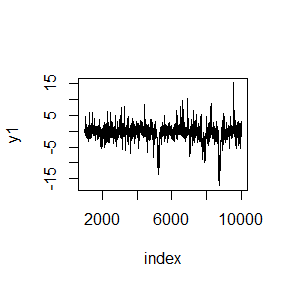

```r
index<-1001:10000
y1<-x[index]
plot(index,y1,type = "l")
```

$$F(x)=\int^x_{-\infty}f(t)dt=1/2+arctanx/\pi$$

$$F^{-1}(q)=tan(\pi(q-1/2))$$

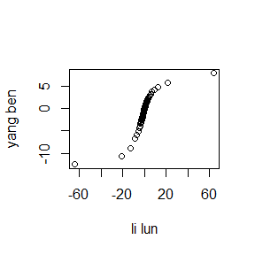

```r
a<-ppoints(100)
QR<-tan(pi*(a-0.5))
Q<-quantile(y1,a)
qqplot(QR,Q,xlab="li lun",ylab="yang ben")
```

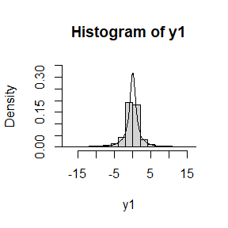

```r
hist(y1,freq = FALSE,ylim = c(0,0.35))
lines(QR,f(QR))
```

```r
a<-c(0.1,0.2,0.3,0.4,0.5,0.6,0.7,0.8,0.9)
QRp<-tan(pi*(a-0.5))
Qp<-quantile(y1,a)
QRp
```

```
## [1] -3.0776835 -1.3763819 -0.7265425 -0.3249197  0.0000000  0.3249197  0.7265425
## [8]  1.3763819  3.0776835
```

```r
Qp
```

```
##        10%        20%        30%        40%        50%        60%        70%
## -3.0249121 -1.4642785 -0.8017586 -0.4290727 -0.1082778  0.2047738  0.5365800
##        80%        90%
##  1.0151406  2.0933415
```

# 9.8

a,b,n is 2,4,10

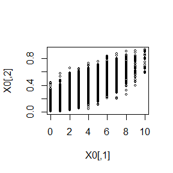

```r
N<-5000
burn<-1000
X<-matrix(0,N,2)
a<-2
b<-4
n<-10
X[1,]<-c(5,0.5)
for(i in 2:N){
  x2<-X[i-1,2]
  X[i,1]<-rbinom(1,n,x2)
  x1<-X[i,1]
  X[i,2]<-rbeta(1,x1+a,n-x1+b)
}
X0<-X[(burn+1):N,]
plot(X0,cex=.5)
```

# 9.3more

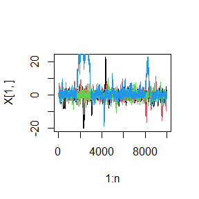

```r
 Gelman.Rubin <- function(psi) {
        # psi[i,j] is the statistic psi(X[i,1:j])
        # for chain in i-th row of X
        psi <- as.matrix(psi)
        n <- ncol(psi)
        k <- nrow(psi)
        psi.means <- rowMeans(psi)     #row means
        B <- n * var(psi.means)        #between variance est.
        psi.w <- apply(psi, 1, "var")  #within variances
        W <- mean(psi.w)               #within est.
        v.hat <- W*(n-1)/n + (B/n)     #upper variance est.
        r.hat <- v.hat / W             #G-R statistic
        return(r.hat)
 }
chain1<-function(m,sigma=1){
f<-function(x){
  return(1/pi/(1+x^2))
}
x<-numeric(m)
x[1]<-rnorm(1,0,sigma)
u<-runif(m)
for(i in 2:m){
  xt<-x[i-1]
  y<-rnorm(1,xt,sigma)
  num<-f(y)*dnorm(xt,y,sigma)
  den<-f(xt)*dnorm(y,xt,sigma)
  if(u[i]<=(num/den))
    x[i]<-y
  else{
    x[i]<-xt
  }
}
return(x)
}
k<-4
n<-10000
b<-1000
X<-matrix(0, nrow=k, ncol=n)
for (i in 1:k){
  X[i, ] <- chain1(n,1)
}

#trace plots
plot(1:n,X[1,],type = "l")
lines(1:n,X[2,],type = "l",col=2)
lines(1:n,X[3,],type = "l",col=3)
lines(1:n,X[4,],type = "l",col=4)
```

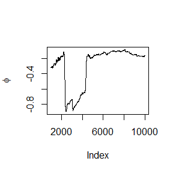

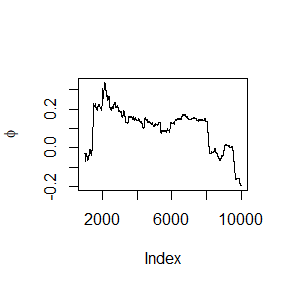

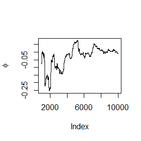

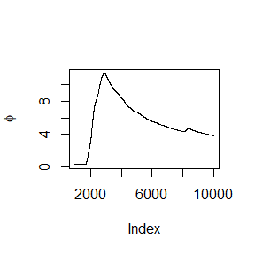

```r
#compute diagnostic statistics
psi <- t(apply(X, 1, cumsum))
for (i in 1:nrow(psi))
    psi[i,] <- psi[i,] / (1:ncol(psi))
#plot psi for the four chains

for (i in 1:k)
    plot((b+1):n,psi[i, (b+1):n], type="l",
            xlab='Index', ylab=bquote(phi))
```

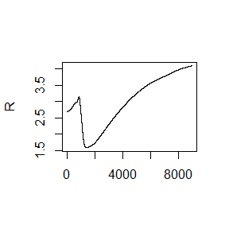

```r
rhat <- rep(0, n)
for (j in (b+1):n)
    rhat[j] <- Gelman.Rubin(psi[,1:j])
plot(rhat[(b+1):n], type="l", xlab="", ylab="R")
abline(h=1.2, lty=2)
```

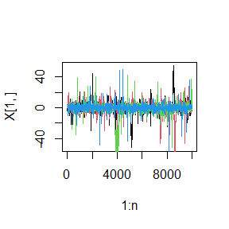

```r
n<-10000
X<-matrix(0, nrow=k, ncol=n)
for (i in 1:k){
  X[i, ] <- chain1(n,5)
}

#trace plots
plot(1:n,X[1,],type = "l")
lines(1:n,X[2,],type = "l",col=2)
lines(1:n,X[3,],type = "l",col=3)
lines(1:n,X[4,],type = "l",col=4)
```

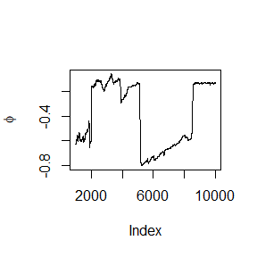

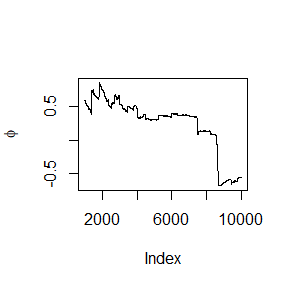

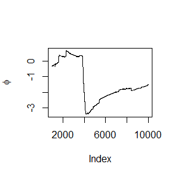

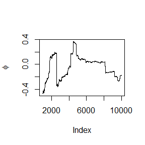

```r
#compute diagnostic statistics
psi <- t(apply(X, 1, cumsum))
for (i in 1:nrow(psi))
    psi[i,] <- psi[i,] / (1:ncol(psi))
#plot psi for the four chains

for (i in 1:k)
    plot((b+1):n,psi[i, (b+1):n], type="l",
            xlab='Index', ylab=bquote(phi))
```

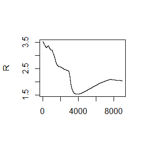

```r
rhat <- rep(0, n)
for (j in (b+1):n)
    rhat[j] <- Gelman.Rubin(psi[,1:j])
plot(rhat[(b+1):n], type="l", xlab="", ylab="R")
abline(h=1.2, lty=2)
```

# 9.8more

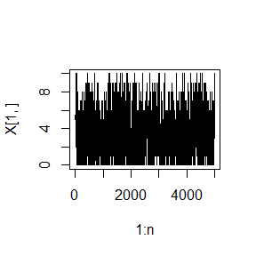

```r
chain2<-function(a,b,n,N){
A<-c()
B<-c()
A[1]<-n/2
B[1]<-0.5
for(i in 2:N){
  x2<-B[i-1]
  A[i]<-rbinom(1,n,x2)
  x1<-A[i]
  B[i]<-rbeta(1,x1+a,n-x1+b)
}
return(A)
}
k<-4
n<-5000
b<-1000
X<-matrix(0, nrow=k, ncol=n)
for (i in 1:k){
  X[i, ] <- chain2(2,4,10,n)
}

#trace plots
plot(1:n,X[1,],type = "l")
```

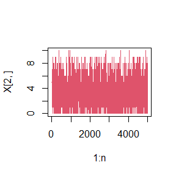

```r
plot(1:n,X[2,],type = "l",col=2)
```

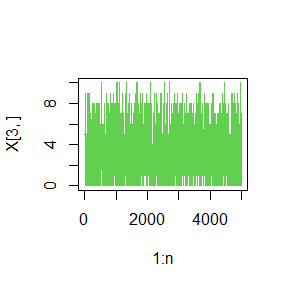

```r
plot(1:n,X[3,],type = "l",col=3)
```

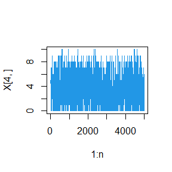

```r
plot(1:n,X[4,],type = "l",col=4)
```

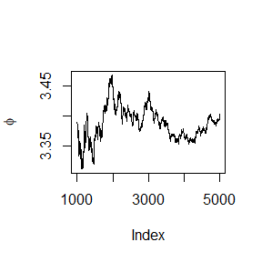

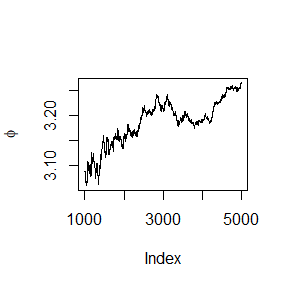

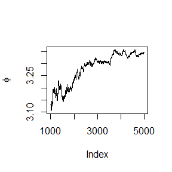

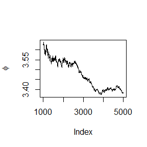

```r
#compute diagnostic statistics
psi <- t(apply(X, 1, cumsum))
for (i in 1:nrow(psi))
    psi[i,] <- psi[i,] / (1:ncol(psi))
#plot psi for the four chains

for (i in 1:k)
    plot((b+1):n,psi[i, (b+1):n], type="l",
            xlab='Index', ylab=bquote(phi))
```

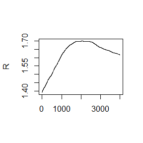

```r
rhat <- rep(0, n)
for (j in (b+1):n)
    rhat[j] <- Gelman.Rubin(psi[,1:j])
plot(rhat[(b+1):n], type="l", xlab="", ylab="R")
abline(h=1.2, lty=2)
```

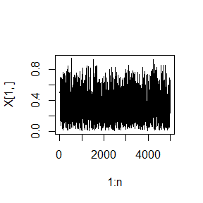

```r
chain2<-function(a,b,n,N){
A<-c()
B<-c()
A[1]<-n/2
B[1]<-0.5
for(i in 2:N){
  x2<-B[i-1]
  A[i]<-rbinom(1,n,x2)
  x1<-A[i]
  B[i]<-rbeta(1,x1+a,n-x1+b)
}
return(B)
}
k<-4
n<-5000
b<-1000
X<-matrix(0, nrow=k, ncol=n)
for (i in 1:k){
  X[i, ] <- chain2(2,4,10,n)
}

#trace plots
plot(1:n,X[1,],type = "l")
```

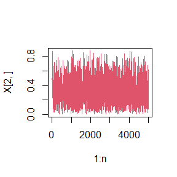

```r
plot(1:n,X[2,],type = "l",col=2)
```

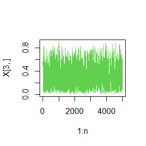

```r
plot(1:n,X[3,],type = "l",col=3)
```

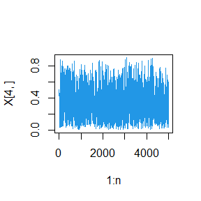

```r
plot(1:n,X[4,],type = "l",col=4)
```

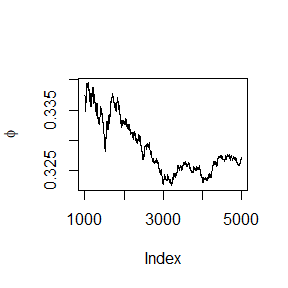

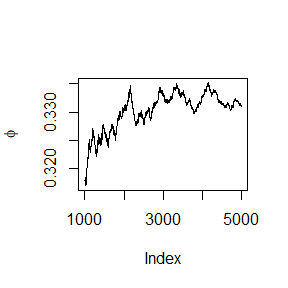

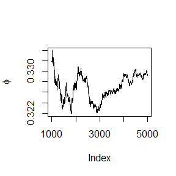

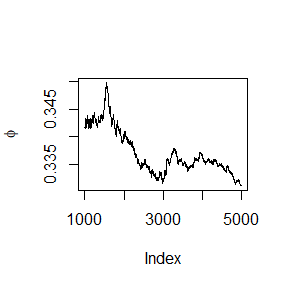

```r
#compute diagnostic statistics
psi <- t(apply(X, 1, cumsum))
for (i in 1:nrow(psi))
    psi[i,] <- psi[i,] / (1:ncol(psi))
#plot psi for the four chains

for (i in 1:k)
    plot((b+1):n,psi[i, (b+1):n], type="l",
            xlab='Index', ylab=bquote(phi))
```

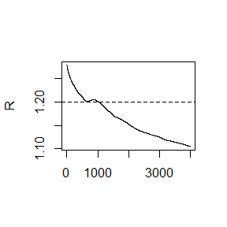

```r
rhat <- rep(0, n)
for (j in (b+1):n)
    rhat[j] <- Gelman.Rubin(psi[,1:j])
plot(rhat[(b+1):n], type="l", xlab="", ylab="R")
abline(h=1.2, lty=2)
```

# 11.3

## (a)

```r
set.seed(12345)
kth<-function(a,k,d){
  s<-1
  if(k%%2==1) s<--1
  g<-exp(lgamma((d+1)/2)+lgamma(k+3/2)-lgamma(k+d/2+1))
  e<-0
  for(j in 1:d){
    e<-e+a[j]^2
  }
  f<-0
  fac<-1
  for(i in 2:k){
    fac<-fac+log(i)
  }
  f<-(k+1)*log(e)-fac-k*log(2)
  f<-exp(f)
  f<-f*s*g/(2*k+1)/(2*k+2)
  return(f)
}
k<-10
d<-10
a<-runif(d,-5,5)
kth(a,k,d)
```

```
## [1] 155500.1
```

```r
a<-runif(d,-3,3)
kth(a,k,d)
```

```
## [1] 11.28007
```

```r
k<-100
d<-10
a<-runif(d,-5,5)
kth(a,k,d)
```

```
## [1] 4.522363e-35
```

```r
a<-runif(d,-3,3)
kth(a,k,d)
```

```
## [1] 1.513206e-46
```

```r
k<-10
d<-2
a<-runif(d,-5,5)
kth(a,k,d)
```

```
## [1] 0.0009048536
```

```r
a<-runif(d,-3,3)
kth(a,k,d)
```

```
## [1] 0.002430449
```

## (b)

```r
kths<-function(a,kk,d){
  ff<-c(length=kk)
  e<-0
  for(j in 1:d){
      e<-e+a[j]^2
    }
  for(k in 1:kk){
    s<-1
    if(k%%2==1) s<--1
    g<-exp(lgamma((d+1)/2)+lgamma(k+3/2)-lgamma(k+d/2+1))
    f<-e*g
    for(i in 1:k){
      f<-f*e/(k+1-i)/2
    }
    ff[k]<-f*s/((2*k+1)*(2*k+2))
  }
  return(sum(ff)+e/2*exp(lgamma((d+1)/2)+lgamma(3/2)-lgamma(d/2+1)))
}

k<-1000
d<-5
a<-runif(d,-2,2)
kths(a,k,d)
```

```
## [1] 2.216767
```

## (c)

$a=(1,2)^T$

```r
d<-2
k<-1000
a<-c(1,2)
kths(a,k,d)
```

```
## [1] 1.532164
```

# 11.5

## 11.4

```r
Sk<-function(a){
  ri1<-sqrt(a^2*(k-1)/(k-a^2))
  y1<-pt(ri1,k-1,0,lower.tail = FALSE)
  ri2<-sqrt(a^2*k/(k+1-a^2))
  y2<-pt(ri2,k,0,lower.tail = FALSE)
  y1-y2
}
k<-25
uniroot(Sk,c(0.01,sqrt(k)))
```

```
## $root
## [1] 1.687318
##
## $f.root
## [1] 7.358151e-09
##
## $iter
## [1] 9
##
## $init.it
## [1] NA
##
## $estim.prec
## [1] 6.103516e-05
```

```r
k<-100
uniroot(Sk,c(0.01,sqrt(k)))
```

```
## $root
## [1] 1.720603
##
## $f.root
## [1] -4.891514e-11
##
## $iter
## [1] 10
##
## $init.it
## [1] NA
##
## $estim.prec
## [1] 6.103516e-05
```

```r
k<-500
uniroot(Sk,c(0.01,3))
```

```
## $root
## [1] 1.729745
##
## $f.root
## [1] 2.267631e-14
##
## $iter
## [1] 7
##
## $init.it
## [1] NA
##
## $estim.prec
## [1] 6.103516e-05
```

```r
k<-1000
uniroot(Sk,c(0.01,3))
```

```
## $root
## [1] 1.730897
##
## $f.root
## [1] 7.549517e-15
##
## $iter
## [1] 7
##
## $init.it
## [1] NA
##
## $estim.prec
## [1] 6.103516e-05
```

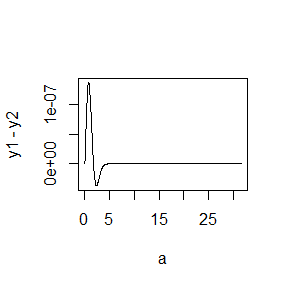

```r
k<-1000
a<-seq(0,sqrt(k),length.out = 1000)
ri1<-sqrt(a^2*(k-1)/(k-a^2))
y1<-pt(ri1,k-1,0,lower.tail = FALSE)
ri2<-sqrt(a^2*k/(k+1-a^2))
y2<-pt(ri2,k,0,lower.tail = FALSE)
plot(a,y1-y2,type="l")
```

## 11.5

```r
k<-25
S1<-function(a){
  f1<-function(x) (1+x^2/(k-1))^(-k/2)
  b1<-integrate(f1,0,sqrt(a^2*(k-1)/(k-a^2)))$value
  c1<-exp(lgamma(k/2)-lgamma(k/2-1/2))/sqrt(k-1)
  f2<-function(x) (1+x^2/k)^(-k/2-1/2)
  b2<-integrate(f2,0,sqrt(a^2*k/(k+1-a^2)))$value
  c2<-exp(lgamma(k/2+1/2)-lgamma(k/2))/sqrt(k)
  b1*c1-b2*c2
}
uniroot(S1,c(0.01,3))
```

```
## $root
## [1] 1.687348
##
## $f.root
## [1] 4.449131e-10
##
## $iter
## [1] 7
##
## $init.it
## [1] NA
##
## $estim.prec
## [1] 6.103516e-05
```

```r
k<-100
uniroot(S1,c(0.01,3))
```

```
## $root
## [1] 1.720626
##
## $f.root
## [1] 6.747034e-10
##
## $iter
## [1] 6
##
## $init.it
## [1] NA
##
## $estim.prec
## [1] 6.103516e-05
```

```r
k<-500
uniroot(S1,c(0.01,3))
```

```
## $root
## [1] 1.729745
##
## $f.root
## [1] -3.18634e-14
##
## $iter
## [1] 7
##
## $init.it
## [1] NA
##
## $estim.prec
## [1] 6.103516e-05
```

```r
k<-1000
uniroot(S1,c(0.01,3))
```

```
## $root
## [1] 1.730897
##
## $f.root
## [1] -1.887379e-15
##
## $iter
## [1] 7
##
## $init.it
## [1] NA
##
## $estim.prec
## [1] 6.103516e-05
```

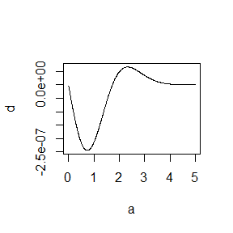

```r
a<-seq(0.01,5,length.out = 1000)
d<-c()
for(i in 1:1000){
  f1<-function(x) (1+x^2/(k-1))^(-k/2)
  b1<-integrate(f1,0,sqrt(a[i]^2*(k-1)/(k-a[i]^2)))$value
  c1<-exp(lgamma(k/2)-lgamma(k/2-1/2))/sqrt(k-1)
  f2<-function(x) (1+x^2/k)^(-k/2-1/2)
  b2<-integrate(f2,0,sqrt(a[i]^2*k/(k+1-a[i]^2)))$value
  c2<-exp(lgamma(k/2+1/2)-lgamma(k/2))/sqrt(k)
  d[i]<-b1*c1-b2*c2
}
plot(a,d,type = "l")
```

# E-M

$$f(t)=\frac{1}{\lambda}\exp(-\frac{t}{\lambda}),t>0$$
。
$$f(t_1,...,t_n)=\frac{1}{\lambda^n}\exp(-\frac{\sum_{i=1}^n t_i}{\lambda})=\frac{1}{\lambda^n}\exp(-\frac{\sum_{i=1}^m x_i+\sum_{j=1}^{n-m}y_j}{\lambda})$$
$$Q(\lambda,\hat\lambda^{(i)})=E[-n\ln\lambda-\frac{\sum_{i=1}^m x_i+\sum_{j=1}^{n-m}y_j}{\lambda}|T_i,\hat\lambda^{(i)}]$$

$$0=E[-n/\lambda+(\sum_{i=1}^m x_i+\sum_{j=1}^{n-m}y_j)/\lambda^2|T_i,\hat\lambda^{(i)}]$$
$$0=-n/\lambda+\sum_{i=1}^m x_i/\lambda^2+E[\sum_{j=1}^{n-m}y_j/\lambda^2|T_i,\hat\lambda^{(i)}]$$
$$\hat\lambda^{(i+1)}=\frac{\sum_{i=1}^mx_i+E[\sum_{j=1}^{n-m}y_j|T_i,\hat\lambda^{(i)}]}{n}$$

$$E[\sum_{j=1}^{n-m}y_j|T_i,\hat\lambda^{(i)}]=(n-m)E[Z],f(z)=\frac{\frac{1}{\lambda}\exp(-\frac{z}{\lambda})}{\exp(-\tau/\lambda)},z>\tau$$
$$E[Z]=\int_\tau^\infty\frac{\frac{z}{\lambda}\exp(-\frac{z}{\lambda})}{\exp(-\tau/\lambda)}dz=\frac{-z\exp(-z/\lambda)-\lambda\exp(-z/\lambda)|_\tau^\infty}{\exp(-\tau/\lambda)}=\frac{(\tau+\lambda)\exp(-\tau/\lambda)}{\exp(-\tau/\lambda)}=\tau+\lambda$$
$$\hat\lambda^{(i+1)}=\frac{\sum_{i=1}^mx_i+(n-m)(\tau+\hat\lambda^{(i)})}{n}=\frac{\sum_{i=1}^ny_i+(n-m)(\hat\lambda^{(i)})}{n}$$

```r
y<-c(0.54,0.48,0.33,0.43,1,1,0.91,1,0.21,0.85)
tau<-1
EM<-function(tau=1,y,max.it=10000,eps=1e-5){
  lam2<-0.1
  lam1<-1
  n<-length(y)
  e=y[which(y[]==1)]
  m<-length(e)
  while(abs(lam1-lam2)>=eps){
    lam1<-lam2
    lam2<-(sum(y)-m+m*(tau+lam2))/n
    print(round(c(lam2),5))
    if(i==max.it) break
    i<-i+1
  }
  return(lam2)
}
EM(1,y)
```

```
## [1] 0.705
## [1] 0.8865
## [1] 0.94095
## [1] 0.95729
## [1] 0.96219
## [1] 0.96366
## [1] 0.9641
## [1] 0.96423
## [1] 0.96427
## [1] 0.96428
## [1] 0.96428
```

```
## [1] 0.9642842
```

：
$$\hat\lambda^{(i+1)}=\frac{\sum_{i=1}^ny_i+(n-m)(\hat\lambda^{(i)})}{n}$$

$$\lambda=\frac{\sum_{i=1}^ny_i+(n-m)\lambda}{n}$$
$$\lambda=\frac{\sum_{i=1}^ny_i}{m}$$

$$l=\frac{1}{\lambda^m}\exp(-\frac{\sum x}{\lambda})\exp(-\frac{(n-m)\tau}{\lambda})$$
$$\log(l)=-m\log(\lambda)-\frac{\sum x}{\lambda}-\frac{(n-m)\tau}{\lambda}$$
$$MLE=\frac{\sum_{i=1}^ny_i}{m}$$

```r
y<-c(0.54,0.48,0.33,0.43,1,1,0.91,1,0.21,0.85)
e=y[which(y[]!=1)]
m<-length(e)
tau<-1
ml<-function(lam=1){
  return(m*log(lam)+
           sum(y)/lam)
}
sum(y)/m
```

```
## [1] 0.9642857
```

```r
library(stats4)
fiy<-mle(ml)
fiy@coef
```

```
##       lam
## 0.9642705
```

# P204 1

```r
set.seed(0)
trims <- c(0, 0.1, 0.2, 0.5)
x <- rcauchy(100)
sum(x)
```

```
## [1] 261.4189
```

```r
median(x)
```

```
## [1] 0.1303608
```

```r
lapply(trims, function(trim) mean(x, trim = trim))
```

```
## [[1]]
## [1] 2.614189
##
## [[2]]
## [1] 0.3893497
##
## [[3]]
## [1] 0.2359156
##
## [[4]]
## [1] 0.1303608
```

```r
lapply(trims, mean, x = x)
```

```
## [[1]]
## [1] 2.614189
##
## [[2]]
## [1] 0.3893497
##
## [[3]]
## [1] 0.2359156
##
## [[4]]
## [1] 0.1303608
```

```r
lapply(trims, sum, x = x)
```

```
## [[1]]
## [1] 261.4189
##
## [[2]]
## [1] 261.5189
##
## [[3]]
## [1] 261.6189
##
## [[4]]
## [1] 261.9189
```

```r
lapply(trims, quantile, x = x)
```

```
## [[1]]
##        0%
## -17.06245
##
## [[2]]
##       10%
## -1.821155
##
## [[3]]
##        20%
## -0.9887048
##
## [[4]]
##       50%
## 0.1303608
```

# P204 5

```r
set.seed(20211126)
data(mtcars)

formulas <- list(
mpg ~ disp,
mpg ~ I(1 / disp),
mpg ~ disp + wt,
mpg ~ I(1 / disp) + wt
)
form<-lapply(formulas,function(formula) lm(formula,data = mtcars))

bootstraps <- lapply(1:10, function(i) {
rows <- sample(1:nrow(mtcars), rep = TRUE)
mtcars[rows, ]})

formulas2<-list(mpg~disp)
lmb<-list()
suppressWarnings(
for(i in 1:10){
  lmb[i]<-lapply(formulas2,function(formula) lm(formula,data = bootstraps[[i]]))
}
)
rsq <- function(mod) summary(mod)$r.squared
a<-c()
b<-c()
for(i in 1:4) a[i]<-rsq(form[[i]])
for(i in 1:10) b[i]<-rsq(lmb[[i]])
a
```

```
## [1] 0.7183433 0.8596865 0.7809306 0.8838038
```

```r
b
```

```
##  [1] 0.7980689 0.7357700 0.7850282 0.6320219 0.6045890 0.6924065 0.8190972
##  [8] 0.7348505 0.8435835 0.8141415
```

```r
mean(b)
```

```
## [1] 0.7459557
```

# P214 1

```r
vapply(mtcars,sd,numeric(1))
```

```
##         mpg         cyl        disp          hp        drat          wt
##   6.0269481   1.7859216 123.9386938  68.5628685   0.5346787   0.9784574
##        qsec          vs          am        gear        carb
##   1.7869432   0.5040161   0.4989909   0.7378041   1.6152000
```

```r
mt<-mtcars
mt[,"mpg"]<-as.character(mt[,"mpg"])
mt[,"mpg"]<-c("a")
mt
```

```
##                     mpg cyl  disp  hp drat    wt  qsec vs am gear carb
## Mazda RX4             a   6 160.0 110 3.90 2.620 16.46  0  1    4    4
## Mazda RX4 Wag         a   6 160.0 110 3.90 2.875 17.02  0  1    4    4
## Datsun 710            a   4 108.0  93 3.85 2.320 18.61  1  1    4    1
## Hornet 4 Drive        a   6 258.0 110 3.08 3.215 19.44  1  0    3    1
## Hornet Sportabout     a   8 360.0 175 3.15 3.440 17.02  0  0    3    2
## Valiant               a   6 225.0 105 2.76 3.460 20.22  1  0    3    1
## Duster 360            a   8 360.0 245 3.21 3.570 15.84  0  0    3    4
## Merc 240D             a   4 146.7  62 3.69 3.190 20.00  1  0    4    2
## Merc 230              a   4 140.8  95 3.92 3.150 22.90  1  0    4    2
## Merc 280              a   6 167.6 123 3.92 3.440 18.30  1  0    4    4
## Merc 280C             a   6 167.6 123 3.92 3.440 18.90  1  0    4    4
## Merc 450SE            a   8 275.8 180 3.07 4.070 17.40  0  0    3    3
## Merc 450SL            a   8 275.8 180 3.07 3.730 17.60  0  0    3    3
## Merc 450SLC           a   8 275.8 180 3.07 3.780 18.00  0  0    3    3
## Cadillac Fleetwood    a   8 472.0 205 2.93 5.250 17.98  0  0    3    4
## Lincoln Continental   a   8 460.0 215 3.00 5.424 17.82  0  0    3    4
## Chrysler Imperial     a   8 440.0 230 3.23 5.345 17.42  0  0    3    4
## Fiat 128              a   4  78.7  66 4.08 2.200 19.47  1  1    4    1
## Honda Civic           a   4  75.7  52 4.93 1.615 18.52  1  1    4    2
## Toyota Corolla        a   4  71.1  65 4.22 1.835 19.90  1  1    4    1
## Toyota Corona         a   4 120.1  97 3.70 2.465 20.01  1  0    3    1
## Dodge Challenger      a   8 318.0 150 2.76 3.520 16.87  0  0    3    2
## AMC Javelin           a   8 304.0 150 3.15 3.435 17.30  0  0    3    2
## Camaro Z28            a   8 350.0 245 3.73 3.840 15.41  0  0    3    4
## Pontiac Firebird      a   8 400.0 175 3.08 3.845 17.05  0  0    3    2
## Fiat X1-9             a   4  79.0  66 4.08 1.935 18.90  1  1    4    1
## Porsche 914-2         a   4 120.3  91 4.43 2.140 16.70  0  1    5    2
## Lotus Europa          a   4  95.1 113 3.77 1.513 16.90  1  1    5    2
## Ford Pantera L        a   8 351.0 264 4.22 3.170 14.50  0  1    5    4
## Ferrari Dino          a   6 145.0 175 3.62 2.770 15.50  0  1    5    6
## Maserati Bora         a   8 301.0 335 3.54 3.570 14.60  0  1    5    8
## Volvo 142E            a   4 121.0 109 4.11 2.780 18.60  1  1    4    2
```

```r
vapply(mt[,which(vapply(mt,is.numeric,logical(1))==TRUE)],sd,numeric(1))
```

```
##         cyl        disp          hp        drat          wt        qsec
##   1.7859216 123.9386938  68.5628685   0.5346787   0.9784574   1.7869432
##          vs          am        gear        carb
##   0.5040161   0.4989909   0.7378041   1.6152000
```

# P214 7

```r
mcsapply<-function(x,a){
library(parallel)
cores <- detectCores()
cluster <- makePSOCKcluster(cores)
c<-unlist(parLapply(cluster, x, a))
return(c)
}
mcvapply<-function(x,a,ty){
library(parallel)
cores <- detectCores()
cluster <- makePSOCKcluster(cores)
c<-unlist(parLapply(cluster, x, a))
for(i in 1:length(c)){
  if(class(c[i])==class(ty[i])) c[i]<-c[i]
    else {c[i]<-as.logical(c[i]);c[i]=FALSE}
}
return(c)
}
a<-function(x) x^2+exp(x)
x<-1:10
system.time(mcsapply(x,a))
```

```
## 用户 系统 流逝
## 0.01 0.12 0.78
```

```r
system.time(sapply(x,a))
```

```
## 用户 系统 流逝
##    0    0    0
```

```r
library(parallel)
cl=makeCluster(2)
system.time(parSapply(cl,x,FUN=function(x) x^2))
```

```
## 用户 系统 流逝
## 0.00 0.00 0.01
```

```r
stopCluster(cl)

b<-numeric(length = 10)
mcvapply(x,a,b)
```

```
##  [1]     3.718282    11.389056    29.085537    70.598150   173.413159
##  [6]   439.428793  1145.633158  3044.957987  8184.083928 22126.465795
```

# 9.8

```r
gibbsR <- function(N,a,b,n) {
  mat <- matrix(nrow = N, ncol = 2)
  x <- y <- 0
  for (i in 1:N) {
    x<-rbinom(1,n,y)
    y<-rbeta(1,x+a,n-x+b)
    mat[i, ] <- c(x, y)
  }
  mat
}
```

```r
library(Rcpp)
dir_cpp <- 'H:/Rp/StatComp21058/src/'
sourceCpp(paste0(dir_cpp,"gibbsC.cpp"))
```

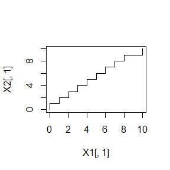

```r
N<-5000
X1<-X2<-matrix(nrow = N, ncol = 2)
X1<-gibbsC(N,2,2,4,10)
X2<-gibbsR(N,2,4,10)
qqplot(X1[,1],X2[,1],type="l")
```

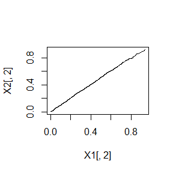

```r
qqplot(X1[,2],X2[,2],type="l")
```

```r
library(microbenchmark)
t<-microbenchmark(X1<-gibbsC(N,2,2,4,10),X2<-gibbsR(N,2,4,10))
t
```

```
## Unit: milliseconds
##                          expr      min        lq      mean    median        uq
##  X1 <- gibbsC(N, 2, 2, 4, 10)  3.28789  3.631776  4.035316  3.818488  4.146512
##     X2 <- gibbsR(N, 2, 4, 10) 21.16269 26.271021 31.862548 31.447915 35.457492
##        max neval
##   8.188726   100
##  50.358018   100
```